# Clinical Trial Efficacy and Safety Analysis

CDISC ADaM Pilot 01

Author

Sushma Gummadi

Published

# Executive summary

This report presents a reproducible efficacy and safety analysis using the publicly available CDISC ADaM Pilot 01 clinical trial data.

The analysis included 254 participants:

- 86 assigned to placebo;
- 84 assigned to Xanomeline High Dose; and
- 84 assigned to Xanomeline Low Dose.

Neither Xanomeline dose demonstrated a statistically significant adjusted efficacy difference compared with placebo at Week 24.

Treatment-emergent adverse events were more frequent in both Xanomeline groups than in the placebo group. Study discontinuation was also substantially higher, while Week 24 completion was lower, in both active treatment groups.

Overall, the findings suggest an uncertain efficacy signal accompanied by a less favourable tolerability profile for Xanomeline.

# Background and objectives

The purpose of this project was to apply a reproducible clinical-trial analytics workflow to publicly available CDISC-standardised data.

The analysis objectives were to:

1. describe the study population;
2. examine ADAS-Cog(11) scores over time;
3. estimate adjusted Week 24 treatment differences;
4. summarise treatment-emergent adverse events;
5. evaluate study discontinuation;
6. evaluate Week 24 completion; and
7. produce a portable clinical-style HTML report.

# Data and methods

## Data source

The analysis used publicly available CDISC ADaM Pilot 01 datasets.

The principal analysis datasets were:

- `ADSL` for participant-level information and treatment assignment;
- `ADQSADAS` for ADAS-Cog(11) efficacy assessments; and
- `ADAE` for adverse-event analyses.

Raw data were imported and processed in earlier project notebooks. Notebook 5 uses the analysis outputs created by those notebooks.

## Analysis populations

The baseline and efficacy analyses included the 254 randomised participants represented in the subject-level analysis dataset.

The safety analysis used participants included in the safety population and their actual treatment assignments.

## Efficacy endpoint

The efficacy endpoint was the ADAS-Cog(11) total score.

Higher ADAS-Cog(11) scores indicate greater cognitive impairment. Therefore, an increase from baseline represents worsening, while a negative active-treatment difference relative to placebo numerically favours Xanomeline.

## Statistical methods

Continuous baseline variables were summarised using medians and interquartile ranges. Categorical variables were summarised using counts and percentages.

The adjusted Week 24 efficacy model included:

- treatment group;
- baseline ADAS-Cog(11) score;
- age; and
- sex.

Placebo was used as the reference treatment.

Adjusted treatment effects are presented with standard errors, 95% confidence intervals, and exploratory p-values.

Safety outcomes were summarised as the number and percentage of participants with at least one event.

# Study population

The randomised population consisted of 254 participants.

Treatment-group sizes were similar:

- Placebo: 86 participants;
- Xanomeline High Dose: 84 participants;
- Xanomeline Low Dose: 84 participants.

The treatment groups were broadly comparable with respect to age, race, body mass index, education level, and baseline cognitive score. Some variation was present in sex distribution and median baseline ADAS-Cog(11) score.

# Efficacy results

## ADAS-Cog(11) trajectory

The following figure presents the unadjusted mean ADAS-Cog(11) score over time by treatment group.

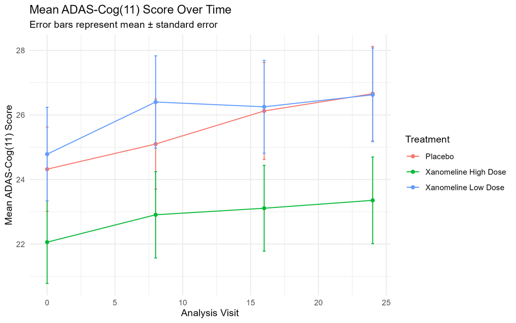

Figure 1: Mean ADAS-Cog(11) score over time by treatment group.

Mean ADAS-Cog(11) scores increased over time in all treatment groups, indicating worsening cognitive performance.

The raw trajectory should not be interpreted as an adjusted treatment comparison because treatment groups differed slightly in their baseline scores.

## Adjusted Week 24 treatment effects

Table 1: Adjusted Week 24 efficacy treatment effects relative to placebo.

**Adjusted Efficacy Treatment Effects**

Treatment comparisons relative to placebo

| Comparison | Estimate | Std.error | Conf.low | Conf.high | P.value |
| --- | --- | --- | --- | --- | --- |
| Xanomeline High Dose vs Placebo | −1.085 | 0.783 | −2.627 | 0.458 | 0.167 |
| Xanomeline Low Dose vs Placebo | −0.541 | 0.776 | −2.070 | 0.988 | 0.486 |

For Xanomeline High Dose versus placebo, the adjusted difference was −1.085 points, with a 95% confidence interval from −2.627 to 0.458 and a p-value of 0.167.

For Xanomeline Low Dose versus placebo, the adjusted difference was −0.541 points, with a 95% confidence interval from −2.070 to 0.988 and a p-value of 0.486.

Both adjusted estimates numerically favoured Xanomeline because they were negative. However, both confidence intervals included zero, and neither comparison was statistically significant.

The analysis therefore did not provide conclusive evidence of a Week 24 treatment effect for either Xanomeline dose.

# Safety results

## Common treatment-emergent adverse events

The following figure presents the most frequently reported treatment-emergent adverse events by treatment group.

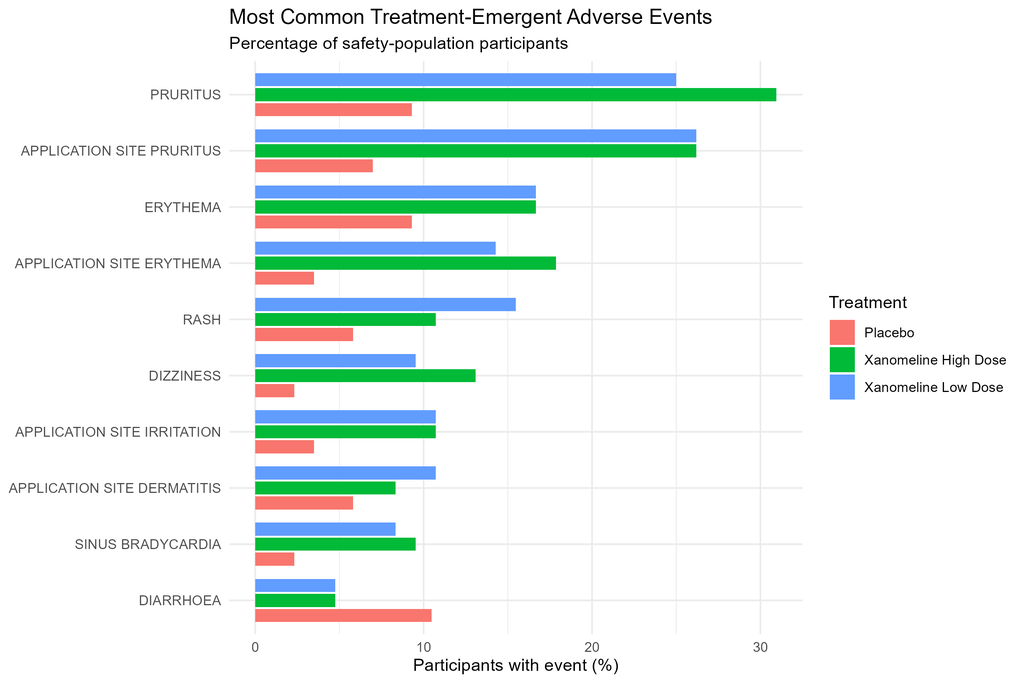

Figure 2: Most common treatment-emergent adverse events by treatment group.

Several dermatological and application-site events were more frequent in the Xanomeline treatment groups than in the placebo group.

## Overall safety summary

Table 2: Participants with at least one treatment-emergent adverse event.

**Overall Treatment-Emergent Adverse Event Summary**

Participants with at least one event, n (%)

| Treatment | Measure | Participants | Denominator | Percent |
| --- | --- | --- | --- | --- |
| Placebo | At least one TEAE | 65 | 86 | 75.581395 |
| Xanomeline High Dose | At least one TEAE | 76 | 84 | 90.476190 |
| Xanomeline Low Dose | At least one TEAE | 77 | 84 | 91.666667 |
| Placebo | At least one fatal TEAE | 2 | 86 | 2.325581 |
| Xanomeline High Dose | At least one fatal TEAE | 0 | 84 | 0.000000 |
| Xanomeline Low Dose | At least one fatal TEAE | 1 | 84 | 1.190476 |
| Placebo | At least one possibly/probably related TEAE | 43 | 86 | 50.000000 |
| Xanomeline High Dose | At least one possibly/probably related TEAE | 70 | 84 | 83.333333 |
| Xanomeline Low Dose | At least one possibly/probably related TEAE | 72 | 84 | 85.714286 |
| Placebo | At least one serious TEAE | 0 | 86 | 0.000000 |
| Xanomeline High Dose | At least one serious TEAE | 2 | 84 | 2.380952 |
| Xanomeline Low Dose | At least one serious TEAE | 1 | 84 | 1.190476 |
| Placebo | At least one severe TEAE | 5 | 86 | 5.813953 |
| Xanomeline High Dose | At least one severe TEAE | 8 | 84 | 9.523810 |
| Xanomeline Low Dose | At least one severe TEAE | 16 | 84 | 19.047619 |

At least one treatment-emergent adverse event occurred in:

- 75.6% of placebo participants;
- 90.5% of Xanomeline High Dose participants; and
- 91.7% of Xanomeline Low Dose participants.

Possibly or probably treatment-related events occurred in:

- 50.0% of placebo participants;
- 83.3% of Xanomeline High Dose participants; and
- 85.7% of Xanomeline Low Dose participants.

At least one severe treatment-emergent adverse event occurred in:

- 5.8% of placebo participants;
- 9.5% of Xanomeline High Dose participants; and
- 19.0% of Xanomeline Low Dose participants.

These findings indicate a less favourable adverse-event profile for both Xanomeline treatment groups.

## Study discontinuation

Table 3: Study discontinuation by treatment group.

**Study Discontinuation Summary**

| Treatment | Participants | Denominator | Percent |
| --- | --- | --- | --- |
| Placebo | 28 | 86 | 32.55814 |
| Xanomeline High Dose | 57 | 84 | 67.85714 |
| Xanomeline Low Dose | 59 | 84 | 70.23810 |

Study discontinuation occurred in:

- 32.6% of placebo participants;
- 67.9% of Xanomeline High Dose participants; and
- 70.2% of Xanomeline Low Dose participants.

Discontinuation was therefore more than twice as frequent in both Xanomeline groups as in the placebo group.

The available adverse-event data did not support determining which study discontinuations were specifically caused by an adverse event because the adverse-event action variable was missing.

## Week 24 completion

Table 4: Week 24 completion by treatment group.

**Week 24 Completion Summary**

| Treatment | Completed | Denominator | Percent |
| --- | --- | --- | --- |
| Placebo | 60 | 86 | 69.76744 |
| Xanomeline High Dose | 30 | 84 | 35.71429 |
| Xanomeline Low Dose | 28 | 84 | 33.33333 |

Week 24 completion was achieved by:

- 69.8% of placebo participants;
- 35.7% of Xanomeline High Dose participants; and
- 33.3% of Xanomeline Low Dose participants.

The lower completion rates in the active-treatment groups correspond with their substantially higher discontinuation rates.

# Data-quality observations

A review of fatal and serious adverse-event records identified an apparent source-data inconsistency.

Some adverse-event records with a fatal outcome were not classified as serious events in the source data.

The source records were retained without modification. The inconsistency should be considered when interpreting serious and fatal adverse-event summaries.

The adverse-event action variable was completely missing. Therefore, the analysis could not determine directly whether individual study discontinuations were caused by adverse events.

# Validation

The report inputs were validated before the analysis sections were rendered.

Validation checks included:

- confirmation that all required CSV and PNG outputs existed;
- treatment denominator checks;
- participant-level adverse-event deduplication;
- endpoint and visit checks;
- missing-value checks;
- confidence-interval review; and
- regression diagnostic review.

Formal independent SAS reproduction has not yet been completed. Therefore, the project should be described as internally validated in R rather than independently validated in both R and SAS.

# Limitations

This analysis has several limitations.

First, it used a public pilot dataset intended for education, standards development, and software demonstration. It should not be interpreted as a regulatory analysis or a definitive reanalysis of the original clinical trial.

Second, the analyses were exploratory and were not based on a prespecified regulatory statistical analysis plan.

Third, the Week 24 efficacy model used an analysis of change from baseline rather than a longitudinal mixed model.

Fourth, no independent missing-data sensitivity analysis was performed.

Fifth, study discontinuation was substantially higher in both Xanomeline treatment groups. This creates an important interpretive concern because results for participants who remained in the analysis may not fully represent participants who discontinued treatment.

Sixth, the adverse-event data contained an apparent inconsistency between fatal outcome and serious-event classifications.

Finally, formal independent SAS validation remains pending.

# Conclusion

Neither Xanomeline dose demonstrated a statistically significant adjusted efficacy difference compared with placebo at Week 24.

Both treatment estimates numerically favoured Xanomeline, but their 95% confidence intervals included zero.

Xanomeline-treated participants experienced higher rates of treatment-emergent adverse events, treatment-related events, severe events, and study discontinuation than placebo-treated participants.

Both Xanomeline groups also had substantially lower Week 24 completion rates.

Overall, the results suggest an uncertain efficacy signal accompanied by a clear tolerability disadvantage for Xanomeline in this exploratory public-data analysis.

# Reproducibility information

**Software Versions**

| Package | Version |
| --- | --- |
| R | 4.6.1 |
| tidyverse | 2.0.0 |
| here | 1.0.2 |
| gt | 1.3.0 |
| knitr | 1.51 |
| quarto | 1.5.1 |